# Geog533 Lab 10

Michael Kezner

November 28, 2017

## Question 1

Use R package UScensus2010county to complete the following tasks: (20 pt.)

```r
if(!require(UScensus2010)) {install.packages("UScensus2010")}
library(UScensus2010)
if(!require(UScensus2010county)) {install.county("osx")}
```

```
UScensus2010county: US Census 2010 County Level Shapefiles and Additional
Demographic Data
Version 1.00 created on 2011-11-06
copyright (c) 2011, Zack W. Almquist, University of California-Irvine
Type help(package="UScensus2010county") to get started.

For citation information, type citation("UScensus2010county").
```

```r
library(UScensus2010county)
library(tmap)
```

### Question 1(a)

Plot a map of New York counties using the plot function.

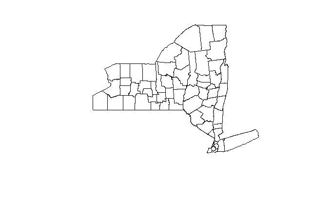

```r
data("new_york.county10")
shp <- new_york.county10
df <- shp@data
plot(shp)
```

### Question 1(b)

Plot a map of New York counties using the qtm function.

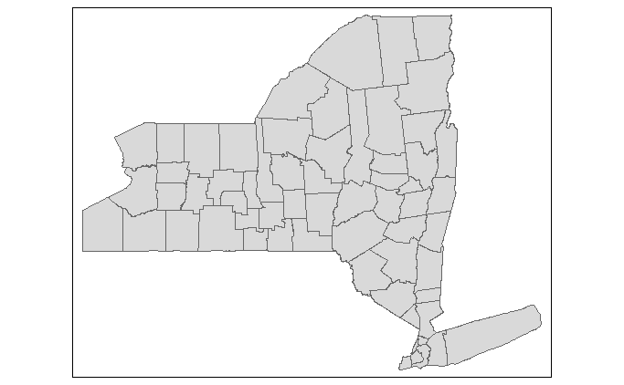

```r
qtm(shp)
```

### Question 1(c)

How many counties in New York State?

```r
NROW(df)
```

```
[1] 62
```

### Question 1(d)

What’s the 3-digit fips code of Broome County?

```r
df[1,4]
```

```
[1] "007"
```

### Question 1(e)

Compute descriptive statistics of the population column (P0010001), including total, minimum, maximum, mean, median, and skewness.

```r
pop1 <- df$P0010001
sum(pop1)
```

```
[1] 19378102
```

```r
min(pop1)
```

```
[1] 4836
```

```r
max(pop1)
```

```
[1] 2504700
```

```r
mean(pop1)
```

```
[1] 312550
```

```r
median(pop1)
```

```
[1] 91301
```

```r
library(moments)
skewness(pop1)
```

```
[1] 2.579801
```

### Question 1(f)

Create a histogram and a boxplot of the population.

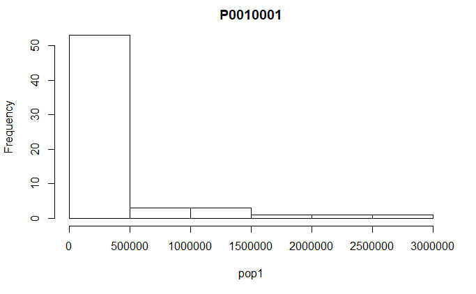

```r
hist(pop1, main = "P0010001")
```

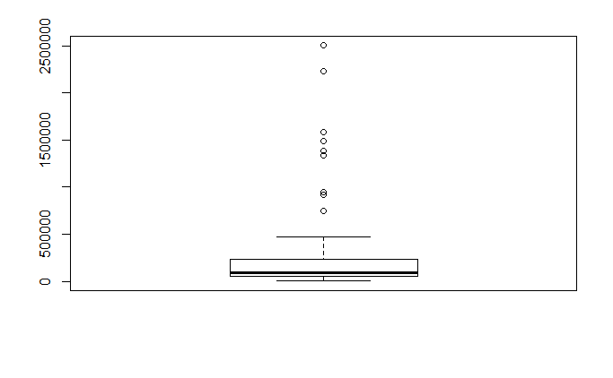

```r
boxplot(pop1)
```

## Question 2

Use R package UScensus2010tract to complete the following tasks: (20 pt.)

```r
if(!require(UScensus2010tract)) {install.tract("osx")}
```

```
UScensus2010tract: US Census 2010 Tract Level Shapefiles and Additional Demographic
Data
Version 1.00 created on 2011-11-06
copyright (c) 2011, Zack W. Almquist, University of California-Irvine
Type help(package="UScensus2010tract") to get started.

For citation information, type citation("UScensus2010tract").
```

```r
library(UScensus2010tract)
```

### Question 2(a)

Plot a map of New York census tracts using the plot function.

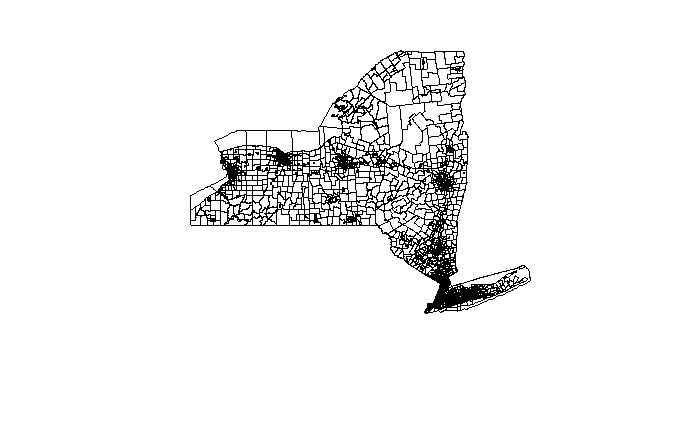

```r
data("new_york.tract10")
shp2 <- new_york.tract10
df2 <- shp2@data
plot(shp2)
```

### Question 2(b)

Compute the total population based on census tracts.

```r
sum(df2$P0010001)
```

```
[1] 19378102
```

### Question 2(c)

Select all census tracts in Broome County and plot the map.

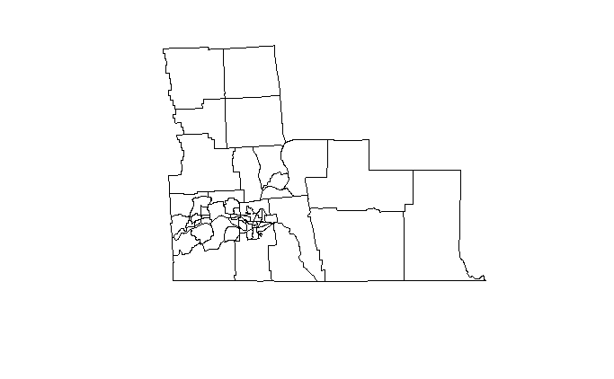

```r
broome <- df2$county == "007"
plot(shp2[broome,])
```

### Question 2(d)

What’s the total population of Broome County?

```r
broomepop <- df2[df2$county == "007",]
sum(broomepop$P0010001)
```

```
[1] 200600
```

### Question 2(e)

Create a histogram and a boxplot of population based on census tracts of Broome County.

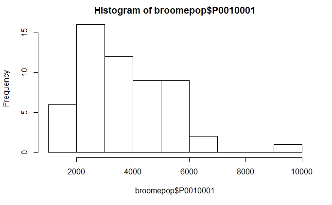

```r
hist(broomepop$P0010001)
```

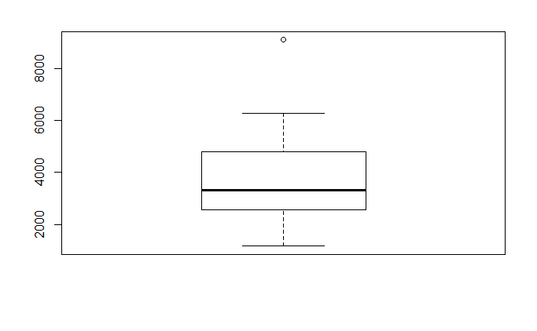

```r
boxplot(broomepop$P0010001)
```

### Question 2(f)

Select the first five columns of the shapefile of Broome County census tract; add a new population ratio column (= census tract population / county population); save the new shapefile to the hard drive.

```r
sel <- data.frame(broomepop[,1:5])
sel$ratio <- broomepop$P0010001/200600
sel
```

|  | state | county | tract | fips | P0010001 | ratio |
| --- | --- | --- | --- | --- | --- | --- |
| new_york.tract10_22 | 36 | 007 | 012500 | 36007012500 | 6274 | 0.031276171 |
| new_york.tract10_46 | 36 | 007 | 011902 | 36007011902 | 2732 | 0.013619143 |
| new_york.tract10_47 | 36 | 007 | 000100 | 36007000100 | 3220 | 0.016051844 |
| new_york.tract10_48 | 36 | 007 | 000200 | 36007000200 | 3188 | 0.015892323 |
| new_york.tract10_49 | 36 | 007 | 000300 | 36007000300 | 2975 | 0.014830508 |
| new_york.tract10_50 | 36 | 007 | 000400 | 36007000400 | 2356 | 0.011744766 |
| new_york.tract10_51 | 36 | 007 | 000500 | 36007000500 | 1969 | 0.009815553 |
| new_york.tract10_52 | 36 | 007 | 000600 | 36007000600 | 2296 | 0.011445663 |
| new_york.tract10_53 | 36 | 007 | 000700 | 36007000700 | 3684 | 0.018364905 |
| new_york.tract10_54 | 36 | 007 | 000900 | 36007000900 | 1762 | 0.008783649 |

[output cut: 45 more lines]

## Question 3

Use R packages raster and ncdf4 to complete the following tasks: (20 pt.)

```r
library(raster)
library(ncdf4)
```

### Question 3(a)

Load the multi-band raster dataset “NDVI.nc” into R.

```r
ndvi <- raster("NDVI.nc")
```

### Question 3(b)

Get the basic information about the dataset, including the number of rows, columns, cells, and bands; spatial resolution, extent, bounding box, and projection.

```r
nrow(ndvi)
```

```
[1] 360
```

```r
ncol(ndvi)
```

```
[1] 720
```

```r
ncell(ndvi)
```

```
[1] 259200
```

```r
nbands(ndvi)
```

```
[1] 36
```

```r
res(ndvi)
```

```
[1] 0.5 0.5
```

```r
extent(ndvi)
```

```
class       : Extent
xmin        : -180
xmax        : 180
ymin        : -90
ymax        : 90
```

```r
bbox(ndvi)
```

```
    min max
s1 -180 180
s2  -90  90
```

```r
projection(ndvi)
```

```
[1] "+proj=longlat +datum=WGS84 +ellps=WGS84 +towgs84=0,0,0"
```

### Question 3(c)

Aggregate all bands to generate a mean NDVI raster and a maximum NDVI raster; save the two new raster datasets to the hard drive.

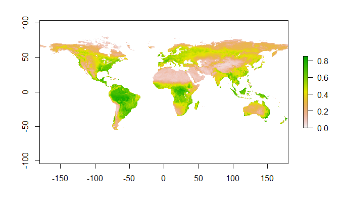

```r
ndvi.rb <- brick("ndvi.nc")
meanndvi <- mean(ndvi.rb)
plot(meanndvi)
```

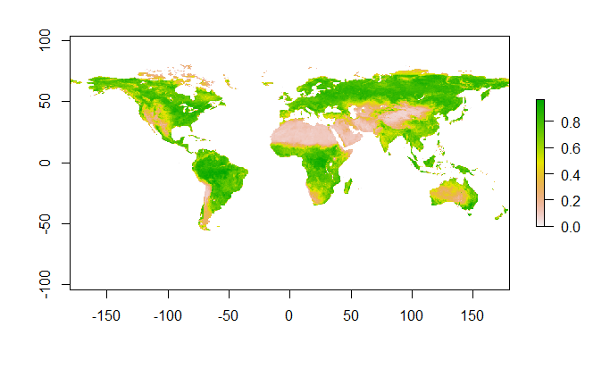

```r
writeRaster(meanndvi,filename = "meanndvi.tif",overwrite=TRUE)
maxndvi <- max(ndvi.rb)
plot(maxndvi)
```

```r
writeRaster(maxndvi,filename = "maxndvi.tif",overwrite=TRUE)
```

### Question 3(d)

Plot the maps of monthly NDVI of the year 2001

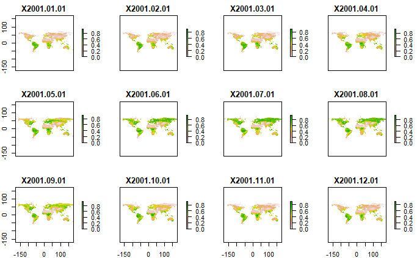

```r
plot(ndvi.rb,13:24)
```

### Question 3(e)

Create histograms of monthly NDVI of the year 2001.

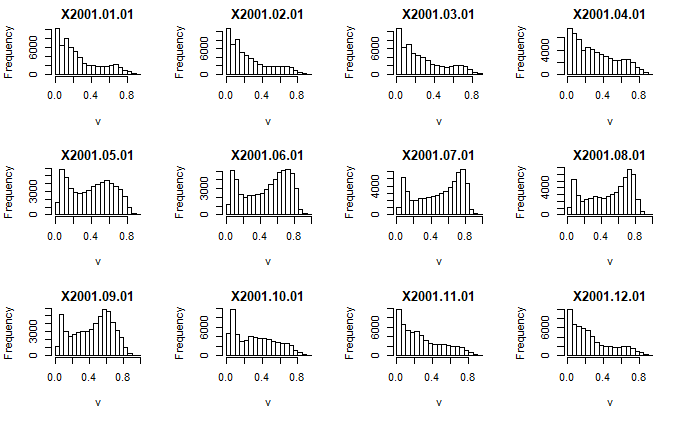

```r
hist(ndvi.rb,13:24)
```

### Question 3(f)

Plot the NDVI map of July 2000; click any location with data on the map and retrieve the NDVI time series for all years; plot the NDVI time series of the selected location.

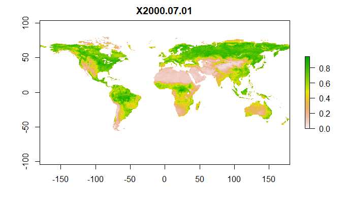

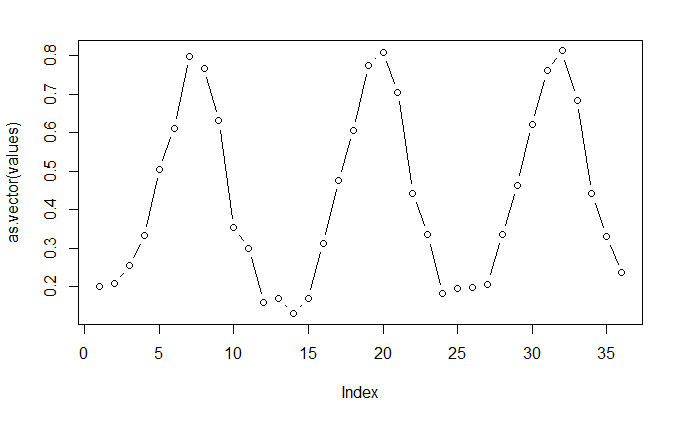